# MCD-1 - Técnicas de predicción: Series Temporales (2022-23)

# Notebook 2 - Modelos

## Practica 3

Gozde Yazganoglu

```python
import pandas as pd
import numpy as np
import matplotlib.pyplot as plt
import seaborn as sns
import matplotlib.pyplot as plt
from sktime.utils.plotting import plot_series, plot_correlations
from sktime.forecasting.ets import AutoETS
from sklearn.metrics import r2_score
import warnings
warnings.filterwarnings('ignore')
```

```python
data_day = pd.read_csv('../data/datos_diarios.csv')
data_week = pd.read_csv('../data/datos_semanales.csv')
```

```python
data_day['Date'] = pd.to_datetime(data_day['Unnamed: 0'])
data_day = data_day.set_index('Date')
data_day = data_day.drop(columns = 'Unnamed: 0' )
data_day
```

| Date | DayOfWeek | Sales | Customers | Open | Promo | StateHoliday | SchoolHoliday |
| --- | --- | --- | --- | --- | --- | --- | --- |
| 2013-01-01 | 20 | 0 | 0 | 0 | 0 | 10 | 10 |
| 2013-01-02 | 30 | 61926 | 7490 | 9 | 0 | 0 | 10 |
| 2013-01-03 | 40 | 53588 | 6650 | 9 | 0 | 0 | 10 |
| 2013-01-04 | 50 | 56578 | 6784 | 9 | 0 | 0 | 10 |
| 2013-01-05 | 60 | 54938 | 6747 | 9 | 0 | 0 | 0 |
| ... | ... | ... | ... | ... | ... | ... | ... |
| 2015-07-27 | 10 | 95402 | 9030 | 10 | 10 | 0 | 8 |
| 2015-07-28 | 20 | 82582 | 8048 | 10 | 10 | 0 | 8 |
| 2015-07-29 | 30 | 78795 | 7851 | 10 | 10 | 0 | 8 |
| 2015-07-30 | 40 | 79610 | 7810 | 10 | 10 | 0 | 9 |
| 2015-07-31 | 50 | 96078 | 9180 | 10 | 10 | 0 | 9 |

942 rows × 7 columns

```python
# Log Transformer Function
from sktime.transformations.series.boxcox import LogTransformer
# Apply Log Transformer
transformer = LogTransformer()
log_data_day = transformer.fit_transform(data_day['Sales'])
```

```python
data_week['Date'] = pd.to_datetime(data_week['Unnamed: 0'])
data_week = data_week.set_index('Date')
data_week = data_week.drop(columns = 'Unnamed: 0' )
```

```python
log_data_week = transformer.fit_transform(data_week['Sales'])
```

```python
# Sktime fucntions
# Forecast horizon and Split functions
from sktime.forecasting.base import ForecastingHorizon
from sktime.forecasting.model_selection import temporal_train_test_split
```

```
900 42
```

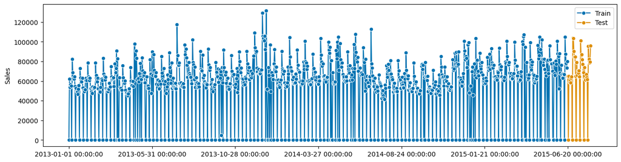

```python
# Select Train & test sample
# we will try to forecast y_test from y_train
# plotting for illustration
# original and log samples
n_test=42
n_forecast=42
y_dtrain, y_dtest = temporal_train_test_split(y =data_day['Sales'], test_size=n_test)
log_y_dtrain, log_y_dtest = temporal_train_test_split(y =log_data_day, test_size=n_test)
plot_series(y_dtrain, y_dtest, labels=["Train", "Test"])
# Time Series Size
print(y_dtrain.shape[0], y_dtest.shape[0])
```

```
129 6
```

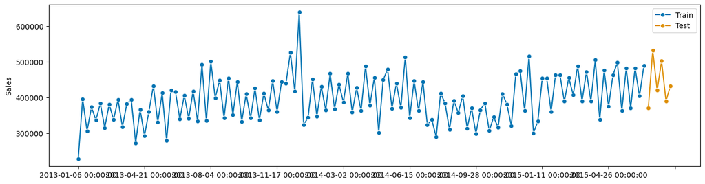

```python
# Select Train & test sample
# we will try to forecast y_test from y_train
# plotting for illustration
# original and log samples
n_test_week=6
n_forecast_week=6
y_wtrain, y_wtest = temporal_train_test_split(y =data_week['Sales'], test_size=n_test_week)
log_y_wtrain, log_y_wtest = temporal_train_test_split(y =log_data_week, test_size=n_test_week)
plot_series(y_wtrain, y_wtest, labels=["Train", "Test"])
# Time Series Size
print(y_wtrain.shape[0], y_wtest.shape[0])
```

## Modelos ETS

### Modelo ETS diario

```python
# specifying forecasting horizon
fh = ForecastingHorizon((np.arange(len(y_dtest)) + 1), freq ='d', is_relative=True)
```

```python
# specifying the forecasting algorithm
ETS_model_day = AutoETS( auto = True, freq='d', sp=365, n_jobs=-1)
```

```python
#  Auto ETS Model Estimation
ETS_model_day.fit(y_dtrain)
```

```
AutoETS(auto=True, freq='d', n_jobs=-1, sp=365)
```

```python
#  Auto ETS Model Summary
print(ETS_model_day.summary())
```

```
                                 ETS Results
==============================================================================
Dep. Variable:                  Sales   No. Observations:                  900
Model:                      ETS(AAdN)   Log Likelihood              -10504.146
Date:                Fri, 20 Jan 2023   AIC                          21020.291
Time:                        14:39:48   BIC                          21049.106
Sample:                    01-01-2013   HQIC                         21031.299
                         - 06-19-2015   Scale                    803645597.012
Covariance Type:               approx
===================================================================================
                      coef    std err          z      P>|z|      [0.025      0.975]
-----------------------------------------------------------------------------------
smoothing_level     0.0024      0.013      0.179      0.858      -0.024       0.028
smoothing_trend     0.0024      0.004      0.666      0.505      -0.005       0.009
damping_trend       0.8548        nan        nan        nan         nan         nan
initial_level    2.817e+04   1.26e+04      2.236      0.025    3474.887    5.29e+04
initial_trend    4026.5515        nan        nan        nan         nan         nan
===================================================================================
Ljung-Box (Q):                       18.15   Jarque-Bera (JB):               153.25
Prob(Q):                              0.00   Prob(JB):                         0.00
Heteroskedasticity (H):               1.24   Skew:                            -1.00
Prob(H) (two-sided):                  0.06   Kurtosis:                         3.29
===================================================================================

Warnings:
[1] Covariance matrix calculated using numerical (complex-step) differentiation.
```

```python
#  Auto ETS Forecasting
day_ETS_pred = ETS_model_day.predict(fh)
print(day_ETS_pred)
```

```
2015-06-20    61745.941648
2015-06-21    61848.859028
2015-06-22    61936.829297
2015-06-23    62012.023284
2015-06-24    62076.296541
2015-06-25    62131.235131
2015-06-26    62178.194764
2015-06-27    62218.334258
2015-06-28    62252.644130
2015-06-29    62281.971038
2015-06-30    62307.038680
2015-07-01    62328.465646
2015-07-02    62346.780686
2015-07-03    62362.435757
2015-07-04    62375.817179
2015-07-05    62387.255163
2015-07-06    62397.031961
2015-07-07    62405.388835
2015-07-08    62412.532006
2015-07-09    62418.637745
2015-07-10    62423.856722
2015-07-11    62428.317726
2015-07-12    62432.130841
2015-07-13    62435.390161
2015-07-14    62438.176116
2015-07-15    62440.557456
2015-07-16    62442.592945
2015-07-17    62444.332811
2015-07-18    62445.819989
2015-07-19    62447.091178
2015-07-20    62448.177747
2015-07-21    62449.106509
2015-07-22    62449.900384
2015-07-23    62450.578961
2015-07-24    62451.158985
2015-07-25    62451.654770
2015-07-26    62452.078550
2015-07-27    62452.440783
2015-07-28    62452.750407
2015-07-29    62453.015063
2015-07-30    62453.241282
2015-07-31    62453.434647
Freq: D, dtype: float64
```

```
(<Figure size 1600x400 with 1 Axes>, <AxesSubplot:ylabel='Sales'>)
```

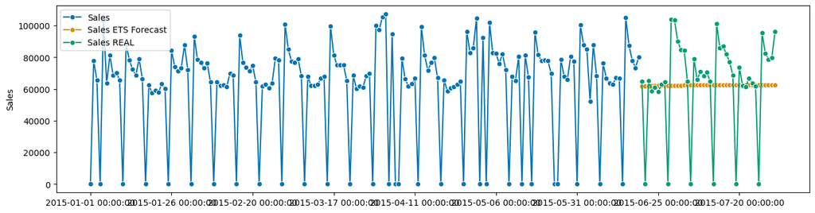

```python
plot_series(y_dtrain['2015-01-01':], day_ETS_pred,y_dtest, labels=["Sales", "Sales ETS Forecast", "Sales REAL"])
```

### Modelo ETS semanal

```python
# specifying forecasting horizon
fhw = ForecastingHorizon((np.arange(len(y_wtest)) + 1), freq ='w', is_relative=True)
```

```python
# specifying the forecasting algorithm
ETS_model_week = AutoETS( auto = True, freq='w', sp= 52, n_jobs=-1)
```

```python
#  Auto ETS Model Estimation
ETS_model_week.fit(y_wtrain)
```

```
AutoETS(auto=True, freq='w', n_jobs=-1, sp=52)
```

```python
#  Auto ETS Model Summary
print(ETS_model_week.summary())
```

```
                                 ETS Results
==============================================================================
Dep. Variable:                  Sales   No. Observations:                  129
Model:                       ETS(MNM)   Log Likelihood               -1554.055
Date:                Fri, 20 Jan 2023   AIC                           3220.109
Time:                        14:39:54   BIC                           3380.259
Sample:                    01-06-2013   HQIC                          3285.181
                         - 06-21-2015   Scale                            0.011
Covariance Type:               approx
=======================================================================================
                          coef    std err          z      P>|z|      [0.025      0.975]
---------------------------------------------------------------------------------------
smoothing_level         0.1727      0.053      3.229      0.001       0.068       0.278
smoothing_seasonal   8.273e-05        nan        nan        nan         nan         nan
initial_level        3.836e+05        nan        nan        nan         nan         nan
initial_seasonal.0      0.8173        nan        nan        nan         nan         nan
initial_seasonal.1      1.5208        nan        nan        nan         nan         nan
initial_seasonal.2      1.0283        nan        nan        nan         nan         nan
initial_seasonal.3      1.3221        nan        nan        nan         nan         nan
initial_seasonal.4      1.2115        nan        nan        nan         nan         nan
initial_seasonal.5      1.0261        nan        nan        nan         nan         nan
initial_seasonal.6      0.9925        nan        nan        nan         nan         nan
initial_seasonal.7      1.1416        nan        nan        nan         nan         nan
initial_seasonal.8      0.9085        nan        nan        nan         nan         nan
initial_seasonal.9      1.0140        nan        nan        nan         nan         nan
initial_seasonal.10     0.8641        nan        nan        nan         nan         nan
initial_seasonal.11     1.0913        nan        nan        nan         nan         nan
initial_seasonal.12     0.9668        nan        nan        nan         nan         nan
initial_seasonal.13     0.9690        nan        nan        nan         nan         nan
initial_seasonal.14     0.9655        nan        nan        nan         nan         nan
initial_seasonal.15     1.0428        nan        nan        nan         nan         nan
initial_seasonal.16     1.0434        nan        nan        nan         nan         nan
initial_seasonal.17     1.1037        nan        nan        nan         nan         nan
initial_seasonal.18     1.0141        nan        nan        nan         nan         nan
initial_seasonal.19     1.0482        nan        nan        nan         nan         nan
initial_seasonal.20     1.0627        nan        nan        nan         nan         nan
initial_seasonal.21     1.2484        nan        nan        nan         nan         nan
initial_seasonal.22     0.8563        nan        nan        nan         nan         nan
initial_seasonal.23     1.1833        nan        nan        nan         nan         nan
initial_seasonal.24     0.8976        nan        nan        nan         nan         nan
```

[output cut: 21 more lines]

```
initial_seasonal.46     1.1766        nan        nan        nan         nan         nan
initial_seasonal.47     1.0611        nan        nan        nan         nan         nan
initial_seasonal.48     1.0519        nan        nan        nan         nan         nan
initial_seasonal.49     1.0235        nan        nan        nan         nan         nan
initial_seasonal.50     1.1707        nan        nan        nan         nan         nan
initial_seasonal.51     1.0000        nan        nan        nan         nan         nan
===================================================================================
Ljung-Box (Q):                       70.07   Jarque-Bera (JB):                18.86
Prob(Q):                              0.00   Prob(JB):                         0.00
Heteroskedasticity (H):               0.46   Skew:                            -0.68
Prob(H) (two-sided):                  0.01   Kurtosis:                         4.29
===================================================================================

Warnings:
[1] Covariance matrix calculated using numerical (complex-step) differentiation.
```

```python
#  Auto ETS Forecasting
week_ETS_pred = ETS_model_week.predict(fhw)
print(week_ETS_pred)
```

```
2015-06-28    384074.321693
2015-07-05    468795.340900
2015-07-12    357510.119275
2015-07-19    471325.333006
2015-07-26    341081.295116
2015-08-02    497236.371394
Freq: W-SUN, dtype: float64
```

```
(<Figure size 1600x400 with 1 Axes>, <AxesSubplot:ylabel='Sales'>)
```

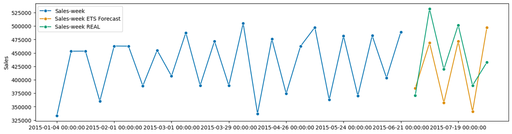

```python
plot_series(y_wtrain['2015-01-01':], week_ETS_pred,y_wtest, labels=["Sales-week", "Sales-week ETS Forecast", "Sales-week REAL"])
```

Modelo semanal predice mejor que modelo diario.

```python
r2ets = r2_score(y_wtest, week_ETS_pred)

r2ets
```

```
0.22981340008354978
```

# ARIMA

## ARIMA diario

Intente poner autoARIMA diario elegiendo sp=356. Pero nos da error. Por eso no utilizamos.

```python
# AutoArima Function
from sktime.forecasting.arima import AutoARIMA
```

## ARIMA semanal

```python
#  Auto ARIMA Model
ARIMA_week = AutoARIMA(sp=52, suppress_warnings=True)
```

```python
#  Auto ARIMA Model Estimation
ARIMA_week.fit(data_week['Sales'])
```

```
AutoARIMA(sp=52, suppress_warnings=True)
```

```python
#  Auto ARIMA Model Summary
print(ARIMA_week.summary())
```

```
                                      SARIMAX Results
===========================================================================================
Dep. Variable:                                   y   No. Observations:                  135
Model:             SARIMAX(1, 1, 1)x(2, 0, [], 52)   Log Likelihood               -1660.763
Date:                             Fri, 20 Jan 2023   AIC                           3331.525
Time:                                     14:42:29   BIC                           3346.015
Sample:                                 01-06-2013   HQIC                          3337.413
                                      - 08-02-2015
Covariance Type:                               opg
==============================================================================
                 coef    std err          z      P>|z|      [0.025      0.975]
------------------------------------------------------------------------------
ar.L1         -0.5163      0.094     -5.495      0.000      -0.700      -0.332
ma.L1         -0.6067      0.064     -9.475      0.000      -0.732      -0.481
ar.S.L52       0.3244      0.099      3.267      0.001       0.130       0.519
ar.S.L104      0.2603      0.150      1.740      0.082      -0.033       0.554
sigma2      3.245e+09   3.43e-11   9.47e+19      0.000    3.25e+09    3.25e+09
===================================================================================
Ljung-Box (L1) (Q):                   3.17   Jarque-Bera (JB):                67.30
Prob(Q):                              0.08   Prob(JB):                         0.00
Heteroskedasticity (H):               0.46   Skew:                             0.66
Prob(H) (two-sided):                  0.01   Kurtosis:                         6.21
===================================================================================

Warnings:
[1] Covariance matrix calculated using the outer product of gradients (complex-step).
[2] Covariance matrix is singular or near-singular, with condition number 2.28e+35. Standard errors may be unstable.
```

```python
#  Auto ARIMA Forecasting
week_ARIMA_pred = ARIMA_week.predict(fhw)
print(week_ARIMA_pred)
```

```
2015-08-09    464382.364247
2015-08-16    418563.926710
2015-08-23    435114.176564
2015-08-30    443810.523351
2015-09-06    437436.446873
2015-09-13    429622.129504
dtype: float64
```

```
(<Figure size 1600x400 with 1 Axes>, <AxesSubplot:ylabel='Sales'>)
```

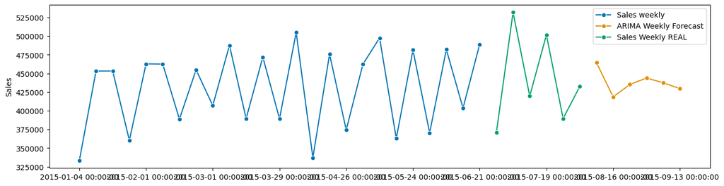

```python
plot_series(y_wtrain['2015-01-01':], week_ARIMA_pred,y_wtest, labels=
            ["Sales weekly", "ARIMA Weekly Forecast", "Sales Weekly REAL"])
```

Los modelos ETS y ARIMA hemos hecho para poder comparar. Pero aparentemente no son muy buenos para datos diarios con vacaciones y otros factores. Por eso vamos a utilizar Prophet.

## Modelo Prophet

Para modelo prophet, el variable independiente debería ser llamada 'y' y deberiamos tener un campo ds para variable temporal.

```python
#adjusting data to prophet.
data_pday= data_day.reset_index()
data_pday = data_pday.rename({'Date' : 'ds', 'Sales' : 'y'}, axis = 1)

data_pweek = data_week.reset_index()
data_pweek = data_pweek.rename({'Date' : 'ds', 'Sales' : 'y'}, axis = 1)

#Dividing into test and train dataframes
day_ptrain = data_pday.iloc[:900,:]
day_ptest = data_pday.iloc[900:,: ]
day_ptest
week_ptrain = data_pweek.iloc[:129,:]
week_ptest = data_pweek.iloc[129:,: ]
week_ptest.head()
```

|  | ds | DayOfWeek | y | Customers | Open | Promo | StateHoliday | SchoolHoliday |
| --- | --- | --- | --- | --- | --- | --- | --- | --- |
| 129 | 2015-06-28 | 280 | 370530 | 43569 | 60 | 0 | 0 | 0 |
| 130 | 2015-07-05 | 280 | 531819 | 52828 | 60 | 50 | 0 | 5 |
| 131 | 2015-07-12 | 280 | 419561 | 46853 | 60 | 0 | 0 | 5 |
| 132 | 2015-07-19 | 280 | 501709 | 51321 | 60 | 50 | 0 | 11 |
| 133 | 2015-07-26 | 280 | 389502 | 43589 | 60 | 0 | 0 | 39 |

```python
from prophet import Prophet
Prophet_daily = Prophet()
Prophet_daily.fit(day_ptrain)
```

```
14:42:30 - cmdstanpy - INFO - Chain [1] start processing
14:42:30 - cmdstanpy - INFO - Chain [1] done processing
```

```
<prophet.forecaster.Prophet at 0x7f9e47ff8070>
```

```python
future = Prophet_daily.make_future_dataframe(periods=len(day_ptest))
forecast = Prophet_daily.predict(future)
#this dataset shows components.
forecast
```

|  | ds | trend | yhat_lower | yhat_upper | trend_lower | trend_upper | additive_terms | additive_terms_lower | additive_terms_upper | weekly | weekly_lower | weekly_upper | yearly | yearly_lower | yearly_upper | multiplicative_terms | multiplicative_terms_lower | multiplicative_terms_upper | yhat |
| --- | --- | --- | --- | --- | --- | --- | --- | --- | --- | --- | --- | --- | --- | --- | --- | --- | --- | --- | --- |
| 0 | 2013-01-01 | 47449.760675 | 34311.226678 | 72904.886547 | 47449.760675 | 47449.760675 | 6934.040415 | 6934.040415 | 6934.040415 | 11347.760418 | 11347.760418 | 11347.760418 | -4413.720003 | -4413.720003 | -4413.720003 | 0.0 | 0.0 | 0.0 | 54383.801090 |
| 1 | 2013-01-02 | 47492.817020 | 29566.432923 | 68837.784246 | 47492.817020 | 47492.817020 | 3147.127313 | 3147.127313 | 3147.127313 | 7585.281809 | 7585.281809 | 7585.281809 | -4438.154496 | -4438.154496 | -4438.154496 | 0.0 | 0.0 | 0.0 | 50639.944333 |
| 2 | 2013-01-03 | 47535.873366 | 27873.177972 | 67696.763314 | 47535.873366 | 47535.873366 | -290.046415 | -290.046415 | -290.046415 | 4066.575367 | 4066.575367 | 4066.575367 | -4356.621782 | -4356.621782 | -4356.621782 | 0.0 | 0.0 | 0.0 | 47245.826951 |
| 3 | 2013-01-04 | 47578.929711 | 32825.016929 | 72094.780451 | 47578.929711 | 47578.929711 | 5193.224767 | 5193.224767 | 5193.224767 | 9369.226470 | 9369.226470 | 9369.226470 | -4176.001702 | -4176.001702 | -4176.001702 | 0.0 | 0.0 | 0.0 | 52772.154479 |
| 4 | 2013-01-05 | 47621.986057 | 29949.987870 | 68479.039457 | 47621.986057 | 47621.986057 | 1251.638642 | 1251.638642 | 1251.638642 | 5156.628447 | 5156.628447 | 5156.628447 | -3904.989805 | -3904.989805 | -3904.989805 | 0.0 | 0.0 | 0.0 | 48873.624698 |
| ... | ... | ... | ... | ... | ... | ... | ... | ... | ... | ... | ... | ... | ... | ... | ... | ... | ... | ... | ... |
| 937 | 2015-07-27 | 60131.666812 | 57892.340782 | 98282.737347 | 60053.519506 | 60200.372448 | 18113.685379 | 18113.685379 | 18113.685379 | 18896.446957 | 18896.446957 | 18896.446957 | -782.761578 | -782.761578 | -782.761578 | 0.0 | 0.0 | 0.0 | 78245.352192 |
| 938 | 2015-07-28 | 60143.882168 | 50758.378697 | 90746.817687 | 60061.312783 | 60215.866678 | 10626.616583 | 10626.616583 | 10626.616583 | 11347.760418 | 11347.760418 | 11347.760418 | -721.143836 | -721.143836 | -721.143836 | 0.0 | 0.0 | 0.0 | 70770.498751 |
| 939 | 2015-07-29 | 60156.097524 | 47708.903317 | 86307.873608 | 60070.165591 | 60231.338570 | 6910.457405 | 6910.457405 | 6910.457405 | 7585.281809 | 7585.281809 | 7585.281809 | -674.824405 | -674.824405 | -674.824405 | 0.0 | 0.0 | 0.0 | 67066.554929 |
| 940 | 2015-07-30 | 60168.312880 | 45152.936059 | 85034.396450 | 60079.837172 | 60248.071293 | 3424.883279 | 3424.883279 | 3424.883279 | 4066.575368 | 4066.575368 | 4066.575368 | -641.692089 | -641.692089 | -641.692089 | 0.0 | 0.0 | 0.0 | 63593.196159 |
| 941 | 2015-07-31 | 60180.528236 | 48947.379346 | 87746.826343 | 60089.284508 | 60263.780638 | 8749.770087 | 8749.770087 | 8749.770087 | 9369.226470 | 9369.226470 | 9369.226470 | -619.456383 | -619.456383 | -619.456383 | 0.0 | 0.0 | 0.0 | 68930.298323 |

942 rows × 19 columns

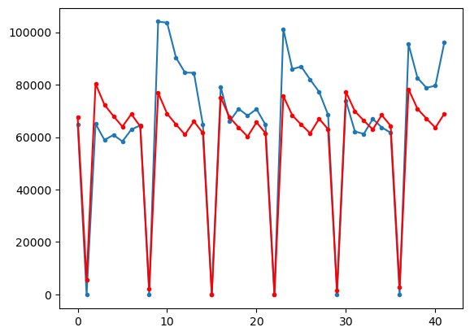

```python
import matplotlib.pyplot as plt
plt.plot(list(day_ptest['y']),'.-')
plt.plot(list(forecast.loc[900:,'yhat']),'r.-')
plt.show()
```

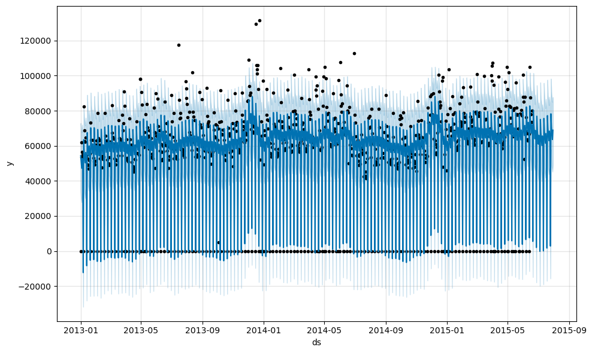

```python
fig1 = Prophet_daily.plot(forecast)
plt.show()
```

#### Prophet con componentes

```python
#adding monthly component.

mp2 = Prophet()
mp2.add_seasonality(name='monthly', period=30.5, fourier_order=5)

mp2.fit(day_ptrain)

future2 = mp2.make_future_dataframe(periods=len(day_ptest))
forecast2 = mp2.predict(future)
from sklearn.metrics import r2_score
print(r2_score(list(day_ptest['y']), list(forecast2.loc[900:,'yhat'] )))
```

```
14:42:32 - cmdstanpy - INFO - Chain [1] start processing
14:42:32 - cmdstanpy - INFO - Chain [1] done processing
```

```
0.794376589988166
```

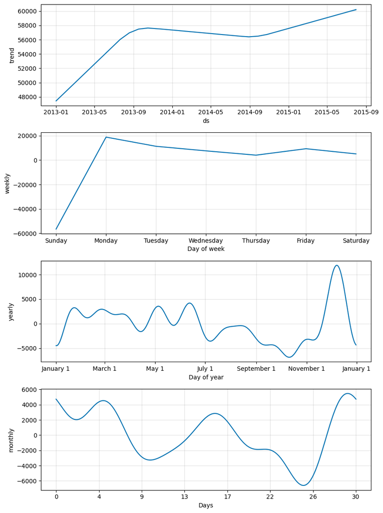

```python
fig2 = mp2.plot_components(forecast2)
plt.show()
```

```python
from sklearn.metrics import r2_score
print(r2_score(list(day_ptest['y']), list(forecast.loc[900:,'yhat'] )))
print(r2_score(list(day_ptest['y']), list(forecast2.loc[900:,'yhat'] )))
```

```
0.77583442748403
0.794376589988166
```

```python
day_ptrain.columns
```

```
Index(['ds', 'DayOfWeek', 'y', 'Customers', 'Open', 'Promo', 'StateHoliday',
       'SchoolHoliday'],
      dtype='object')
```

```python
# Add the holidays to the model
P_daily_customer = Prophet()
P_daily_customer.add_regressor( 'Customers', prior_scale=0.1)
P_daily_customer.add_regressor( 'Open', prior_scale=0.1)
P_daily_customer.add_regressor( 'Promo', prior_scale=0.1)
P_daily_customer.add_regressor( 'DayOfWeek', prior_scale=0.1)
P_daily_customer.fit(day_ptrain)

future_c = P_daily_customer.make_future_dataframe(periods=len(day_ptest))
future_c = future_c.append(day_ptest)
future_c = future_c[['Customers','Open','Promo','ds','y','DayOfWeek']]
```

```
14:42:34 - cmdstanpy - INFO - Chain [1] start processing
14:42:34 - cmdstanpy - INFO - Chain [1] done processing
```

```python
forecast_c = P_daily_customer.predict(future_c.dropna())
```

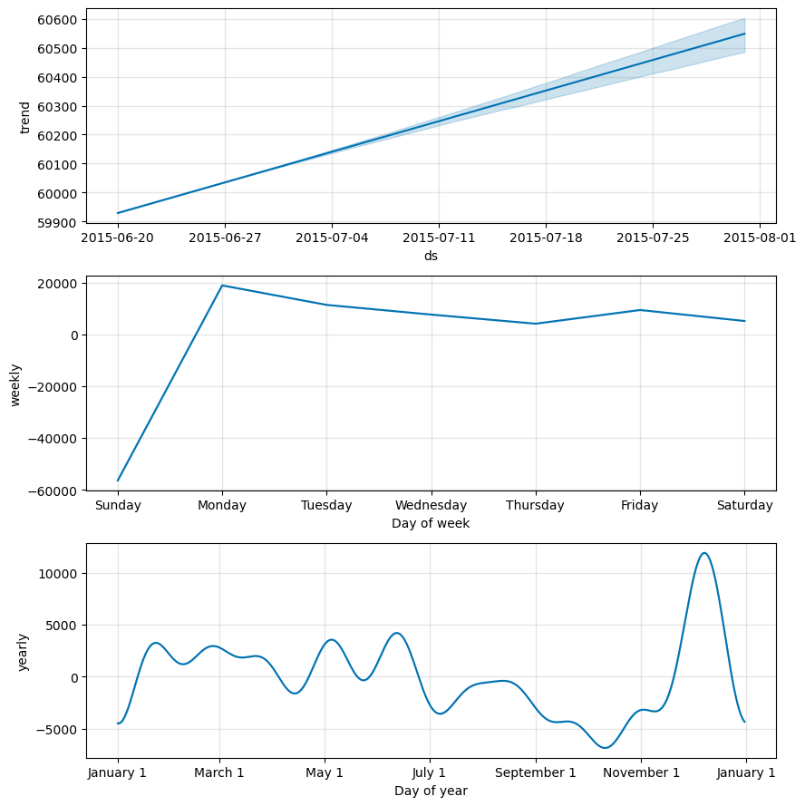

```python
fig2 = mp2.plot_components(forecast_c)
plt.show()
```

```python
forecast_c.head()
```

|  | ds | trend | yhat_lower | yhat_upper | trend_lower | trend_upper | Customers | Customers_lower | Customers_upper | DayOfWeek | ... | weekly | weekly_lower | weekly_upper | yearly | yearly_lower | yearly_upper | multiplicative_terms | multiplicative_terms_lower | multiplicative_terms_upper | yhat |
| --- | --- | --- | --- | --- | --- | --- | --- | --- | --- | --- | --- | --- | --- | --- | --- | --- | --- | --- | --- | --- | --- |
| 0 | 2015-06-20 | 59929.204407 | 61744.481093 | 67626.131749 | 59929.204407 | 59929.204407 | 8889.840033 | 8889.840033 | 8889.840033 | 6044.925154 | ... | -3376.693572 | -3376.693572 | -3376.693572 | -478.667749 | -478.667749 | -478.667749 | 0.0 | 0.0 | 0.0 | 64845.692362 |
| 1 | 2015-06-21 | 59944.302941 | 368.429039 | 6329.668594 | 59944.302941 | 59944.302941 | -73768.193114 | -73768.193114 | -73768.193114 | 8946.025053 | ... | -6857.963480 | -6857.963480 | -6857.963480 | -511.447605 | -511.447605 | -511.447605 | 0.0 | 0.0 | 0.0 | 3411.480988 |
| 2 | 2015-06-22 | 59959.401475 | 65038.313232 | 70728.308814 | 59959.401475 | 59959.401475 | 14950.049197 | 14950.049197 | 14950.049197 | -8460.574336 | ... | 8173.442184 | 8173.442184 | 8173.442184 | -528.837874 | -528.837874 | -528.837874 | 0.0 | 0.0 | 0.0 | 67930.564734 |
| 3 | 2015-06-23 | 59974.500009 | 56072.905521 | 61749.654480 | 59974.500009 | 59974.500009 | 6348.461997 | 6348.461997 | 6348.461997 | -5559.474438 | ... | 4922.731027 | 4922.731027 | 4922.731027 | -528.847836 | -528.847836 | -528.847836 | 0.0 | 0.0 | 0.0 | 58994.454846 |
| 4 | 2015-06-24 | 59989.598542 | 59272.197023 | 64807.624869 | 59989.598542 | 59989.598542 | 9211.824581 | 9211.824581 | 9211.824581 | -2658.374540 | ... | 2204.240346 | 2204.240346 | 2204.240346 | -509.776573 | -509.776573 | -509.776573 | 0.0 | 0.0 | 0.0 | 62074.596445 |

5 rows × 34 columns

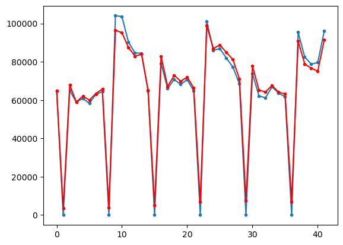

```python
plt.plot(list(day_ptest['y']),'.-')
plt.plot(list(forecast_c['yhat']),'r.-')
plt.show()
```